# Workshop 10 - Data Visualisation II

Elisabeth Busch-Nentwich

# 1. Introduction

Last week we focused on the elements that directly display your data, the geometric objects. We also added various labels, such as title and subtitle, and changed the legend title and labels. This week we will do a bit more on labelling data points and then look into manipulating the optics of your graphic using `theme()`, colour palettes and ways to arrange several plots in one figure.

# 2. Annotating data points

We often want to highlight specific data points in our graphic by labeling them individually. For example, the graph below shows differentially expressed genes with top changers individually labelled.

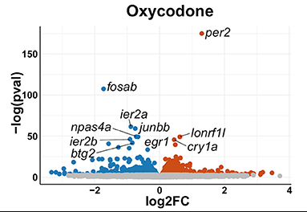

From Mech and Merteroglu et al., https://doi.org/10.3389/fpsyt.2021.795175

We’ll use our penguin friends from last week again as the example dataset.

```r
install.packages("palmerpenguins")
library(palmerpenguins)
library(tidyverse)
```

Let’s say we would like to label the five biggest Gentoo penguins with names in a scatterplot. We can subset our dataframe to the five heaviest Gentoo penguins and add a column with names. We can then use that dataframe to label the dots.

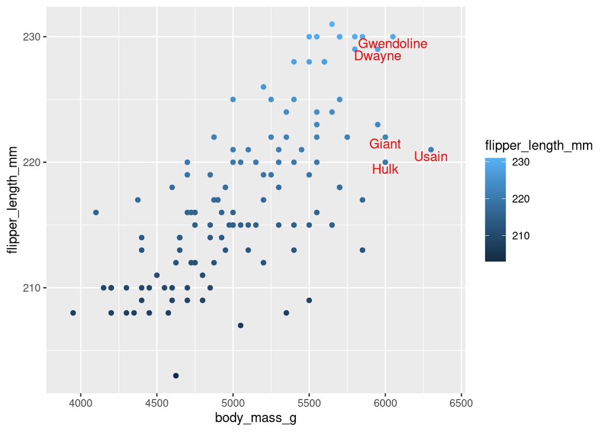

```r
# Subset penguins dataframe to the the five heaviest penguins
big_penguins <- penguins %>%
  filter(species == "Gentoo",!is.na(body_mass_g)) %>%
  arrange(body_mass_g) %>% tail(n = 5L)

# Add a column with names to big_penguins
big_penguins$names <- c("Dwayne", "Hulk", "Giant", "Gwendoline", "Usain")

# Plot all Gentoo penguins and use big_penguins dataframe for labels
penguins %>% filter(species == "Gentoo") %>%
  ggplot(aes(x = body_mass_g, y = flipper_length_mm)) +
  geom_point(aes(colour = flipper_length_mm)) +
  geom_text(
    data = big_penguins,
    mapping = aes(label = names),
    nudge_x = -1.5,
    nudge_y = -0.5,
    colour = "red"
  ) +
  xlim(3900, 6400)
```

There are a few important details to note about the code above:

1. For `geom_text()` we’re switching to different data, namely our big_penguins dataframe. Nevertheless, `geom_text()` inherits the position mappings from `ggplot()`. That’s how `geom_text()` knows where to put the labels.
2. We use the nudge parameters to push the labels down and left a bit, so that they don’t sit right on top of the dots they are labeling.
3. We’ve made the x-axis a bit longer with `xlim()`, so that the names don’t get cut off.

If your desired labels are already in your dataframe you can filter within the data argument to geom_text. For example, I want to highlight the home islands of Adelie penguins with flipper lengths over 200 mm:

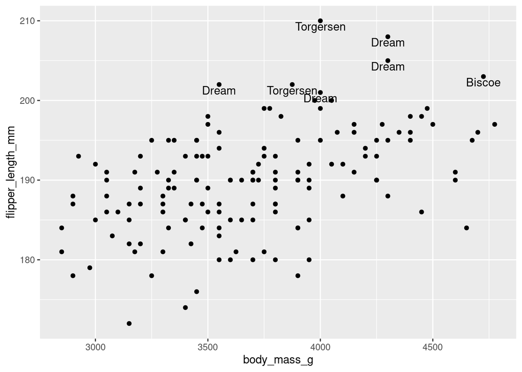

```r
penguins %>% filter(species == "Adelie") %>%
  ggplot(aes(x = body_mass_g, y = flipper_length_mm)) +
  geom_point() +
  geom_text(
    data = filter(penguins, species == "Adelie" &
                    flipper_length_mm > 200),
    aes(label = island),
    nudge_y = -0.7
  )
```

**Why do we have to filter for the species again in `geom_text()`? What happens if we don’t do that?**

**Produce the following plot. Plotted here are only the penguins resident on the island Biscoe.**

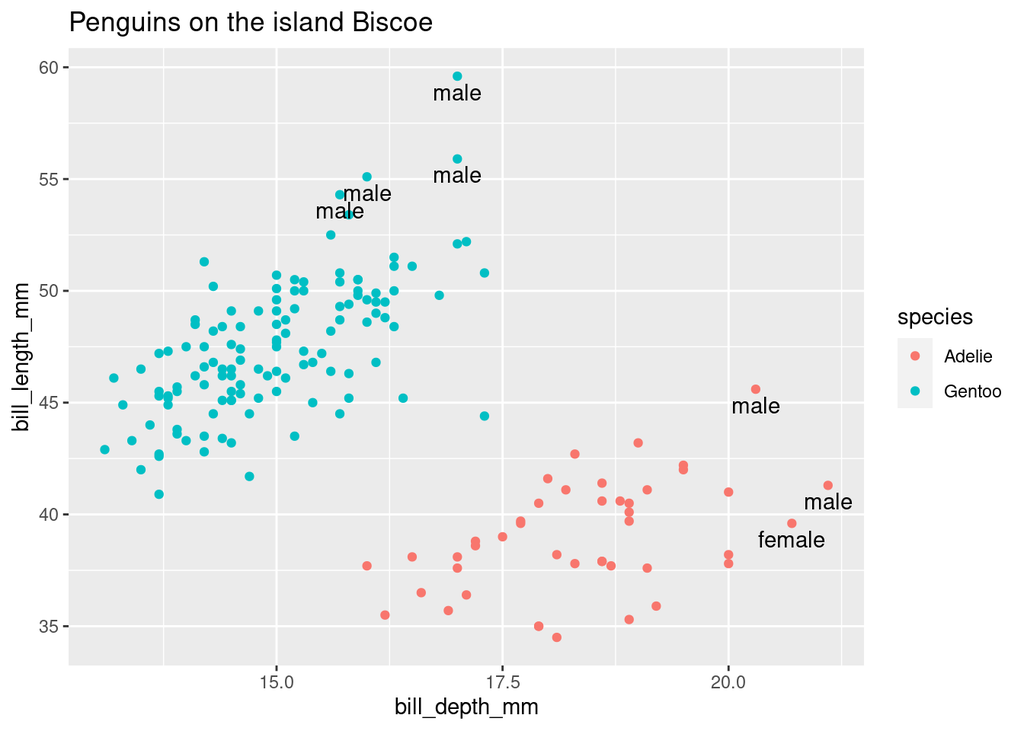

# 3. Facets

So far we have shown all our data in one plot, and then mapped, for example, species to colour to see species differences. Another nice way to separate subsets of data is faceting where you produce several small plots separated by categorical variables. There are two types of faceting, `facet_wrap()` and `facet_grid()`. The first takes a number of plots and “wraps” them into a panel. Let’s go back to our malaria modeling data for an example:

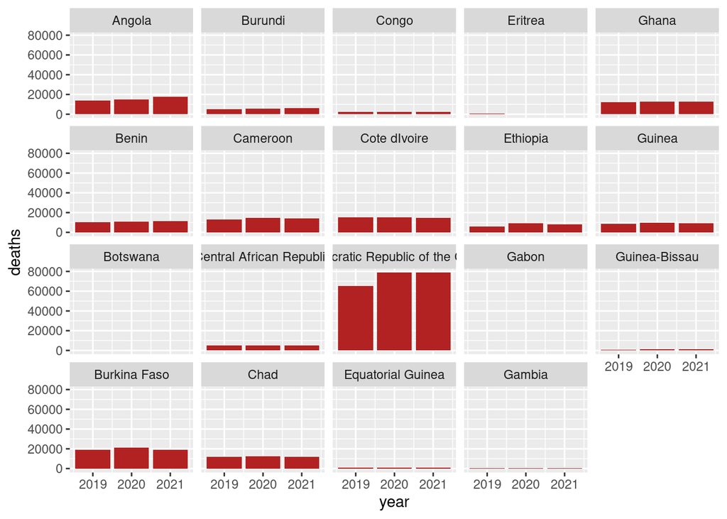

```r
# Reading in data
modeltab <- read.table("wmr_modelling.txt",sep="\t",header=T)

# Subsetting to the first half or so for readability
modeltab_short <- head(modeltab, n = 506L)

# Plotting deaths in years 2019-2021 faceted by country
modeltab_short %>% drop_na() %>% filter(year >2018) %>%
  ggplot(aes(x = year, y = deaths)) +
  geom_col(fill = "firebrick") +
  facet_wrap(~country, ncol = 5, dir = "v")
```

As you can see `~` determines the variable by which we want to split our data into separate plots. We can choose the number of rows and columns with `ncol` or `nrow` (One follows from the other, so you only need to set one). `dir` controls the direction of the wrap.

**Copy the code above and play around with different options. What does the `facet_wrap()` argument `as.table` do? What happens if you set the argument `scales` to “free”? (Also note that we use the function `drop_na()`. Have a look at its documentation.)**

The second faceting type lays out the plots in a 2D grid. This is often used to separate plots by two categorical variables like so:

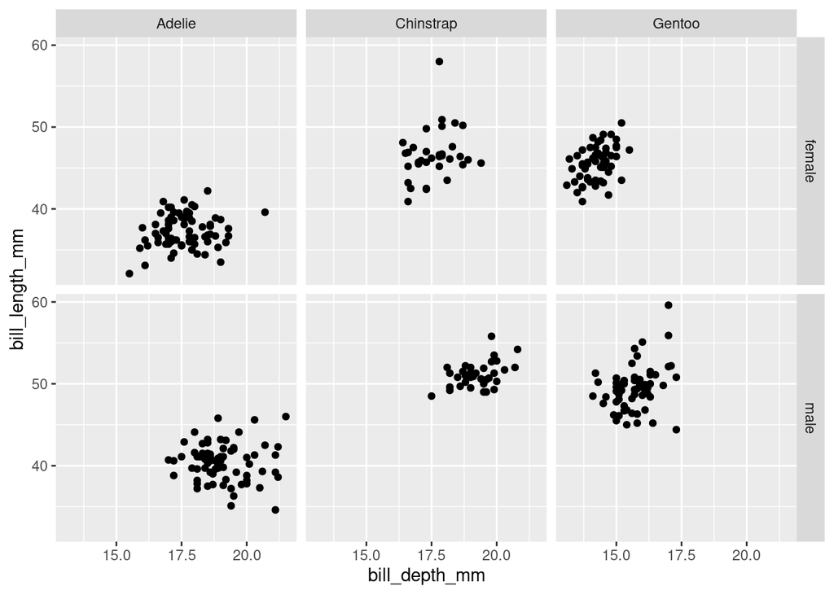

```r
penguins %>% drop_na() %>% ggplot(aes(x = bill_depth_mm, y = bill_length_mm)) +
  geom_point() +
  facet_grid(sex ~ species)
```

The formula in `facet_grid()` determines first the rows, then the columns. You can also use this to control how you want plots laid out that are separated by just one variable:

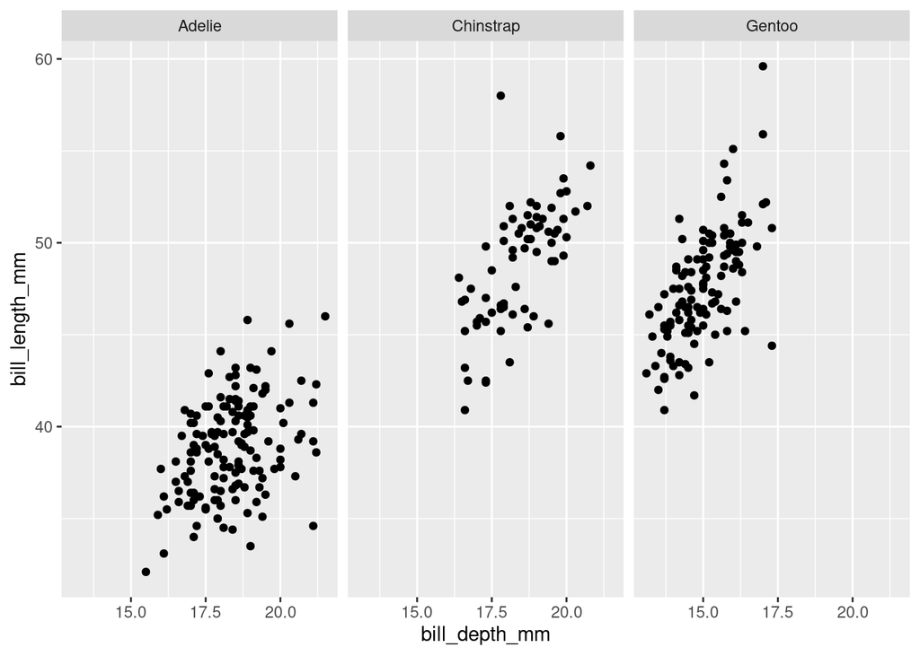

```r
p_plot <- penguins %>% drop_na() %>%
  ggplot(aes(x = bill_depth_mm, y = bill_length_mm)) +
  geom_point()


p_plot + facet_grid(. ~ species)
```

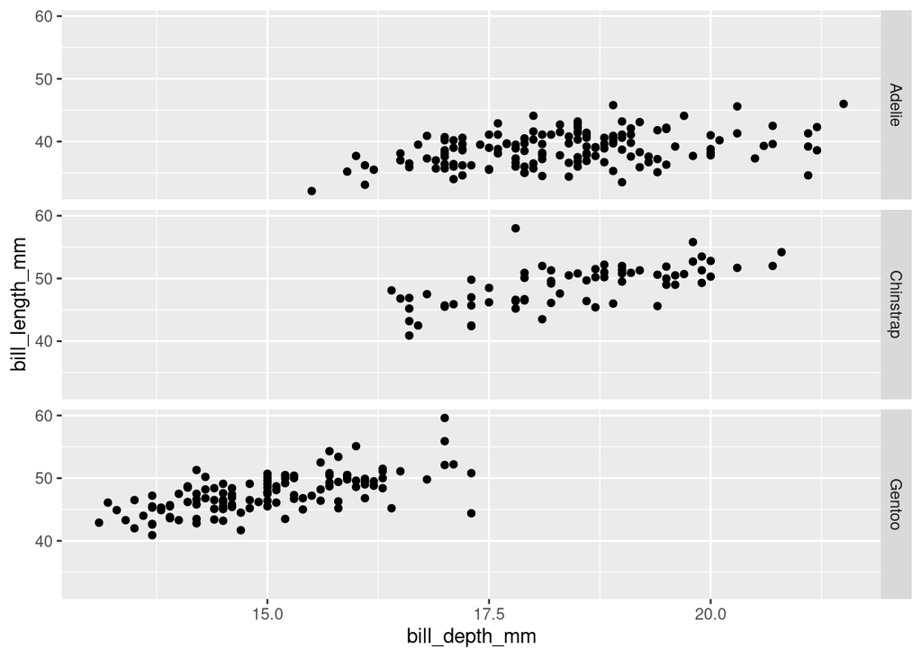

```r
p_plot + facet_grid(species ~ .)
```

**Produce this plot using the dataset in the file called wmr_cases_deaths_modelling_summaries.txt**

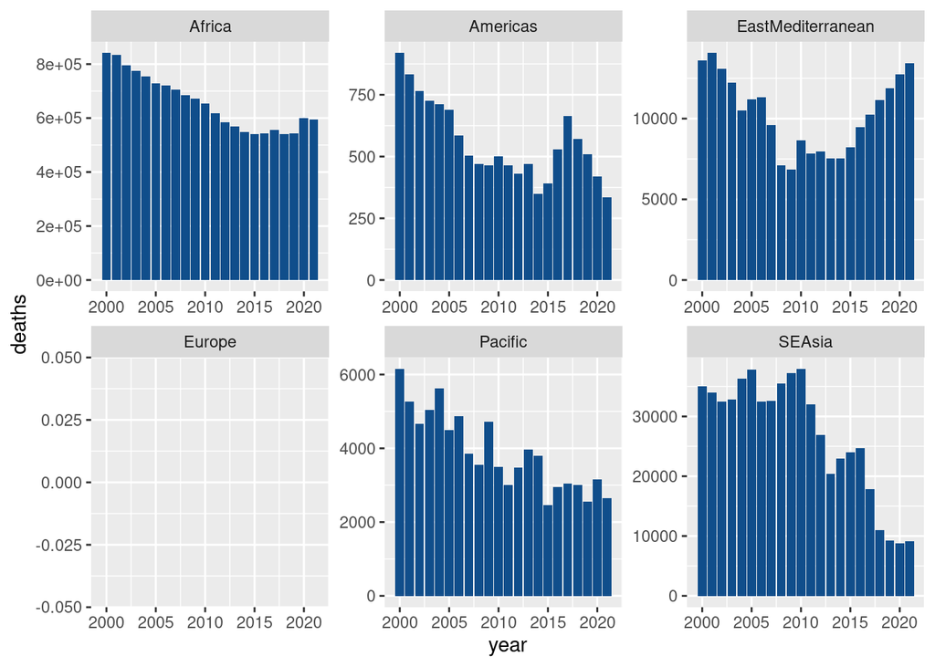

# 4. Patchwork

When we publish papers or produce figures for a presentation we often need to combine several panels into a larger figure. There is a package called patchwork that can do that for us.

```r
install.packages("patchwork")
library(patchwork)
```

First, let’s produce some plots:

```r
p1 <- penguins %>% drop_na() %>%
  ggplot(aes(x = bill_depth_mm, y = bill_length_mm, colour = species)) +
  geom_point() + facet_grid(. ~ species)

p2 <- penguins %>%  drop_na() %>%
  ggplot(aes(x = flipper_length_mm)) +
  geom_histogram(aes(fill = species), position = "identity")

p3 <- penguins %>% drop_na() %>%
  ggplot(aes(x = species, y = body_mass_g)) +
  geom_violin(aes(fill = sex))
```

Patchwork stitches these plot together using an intuitive formula approach:

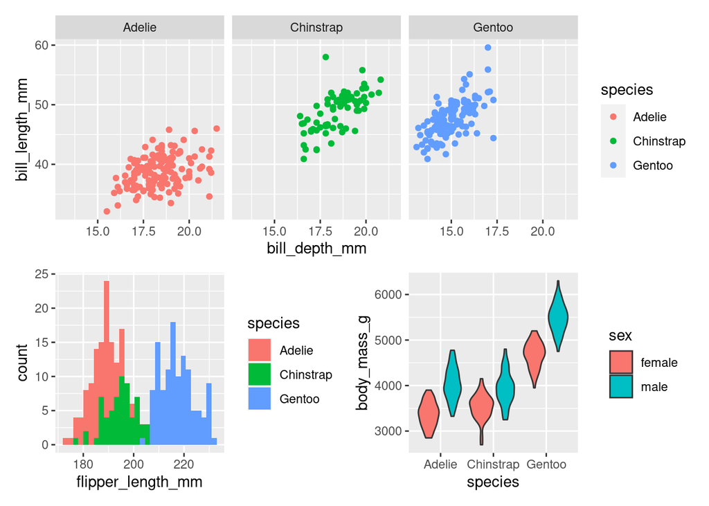

```r
p1/(p2+p3)
```

We can also say that we want only one plot on the left, and the other two stacked on the right:

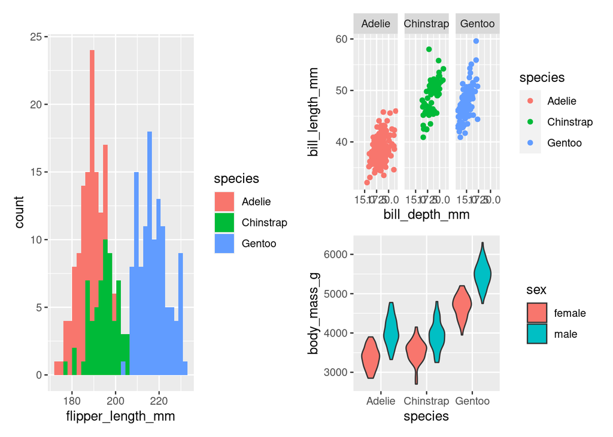

```r
p2 | (p1/p3)
```

Patchwork allows you to add annotations using the `plot_annotation()` function:

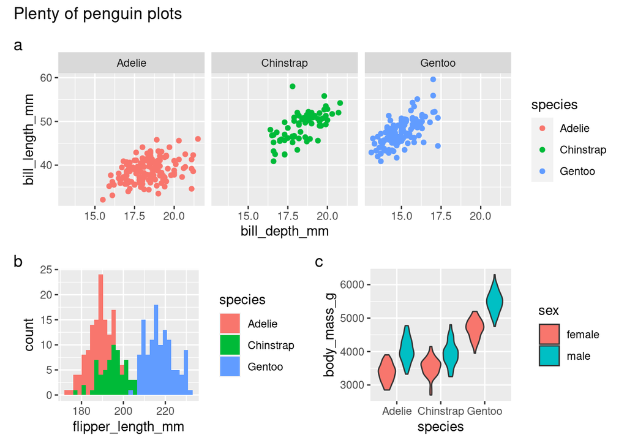

```r
p1/(p2+p3) + plot_annotation(tag_levels = "a",
                           title = "Plenty of penguin plots")
```

Patchwork is very useful when we want to align plots with the same x- or y-axis:

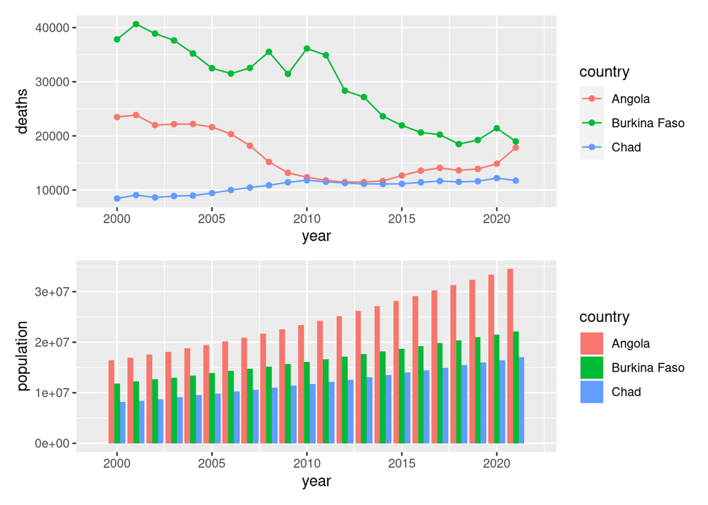

```r
p_deaths <- modeltab %>% filter(country %in% c("Angola", "Burkina Faso", "Chad")) %>%
  ggplot(aes(x = year, y = deaths, colour = country)) +
  geom_point() +
  geom_line() +
  xlim(1999,2022)

p_pop <- modeltab %>% filter(country %in% c("Angola", "Burkina Faso", "Chad")) %>%
  ggplot(aes(x = year, y = population, fill = country)) +
  geom_col(position = "dodge") +
  xlim(1999,2022)

p_deaths/p_pop
```

Note that there is a new operator, `%in%`, in the code above. It’s extremely handy for subsetting. Here it’s used with a vector written on the fly, but you can also use a variable that contains a vector you made previously.

**Using the datasets in wmr_modelling.txt and wmr_cases_deaths_modelling_summaries.txt produce a publication-style figure. It should contain at least three plots, one with faceting, arranged with patchwork.**

# 5. Colours

We have already started to manipulate some colours manually, but there is a whole world of colour palettes, and ways to use them, out there. There are loads of packages with colour schemes out there. Here, we will focus on those that inbuilt in ggplot2, but feel free to go and explore.

In principle, we use colours in three ways: We map either categorical or continuous variables to them, or we manually colour geometric elements independently from a variable.

**Scroll up through this worksheet and identify one plot each for the three ways of using colour.**

## Discrete colour scales

You’ve seen already last week that we can change colours manually. For this you can use the built-in colour names in R. There are 657 of them! You can get their names with `colours()`. Alternatively you can use hexadecimal colour codes. You can see what the colours look like here: https://rpubs.com/kylewbrown/r-colors

Here is an example of how to change discrete colours manually:

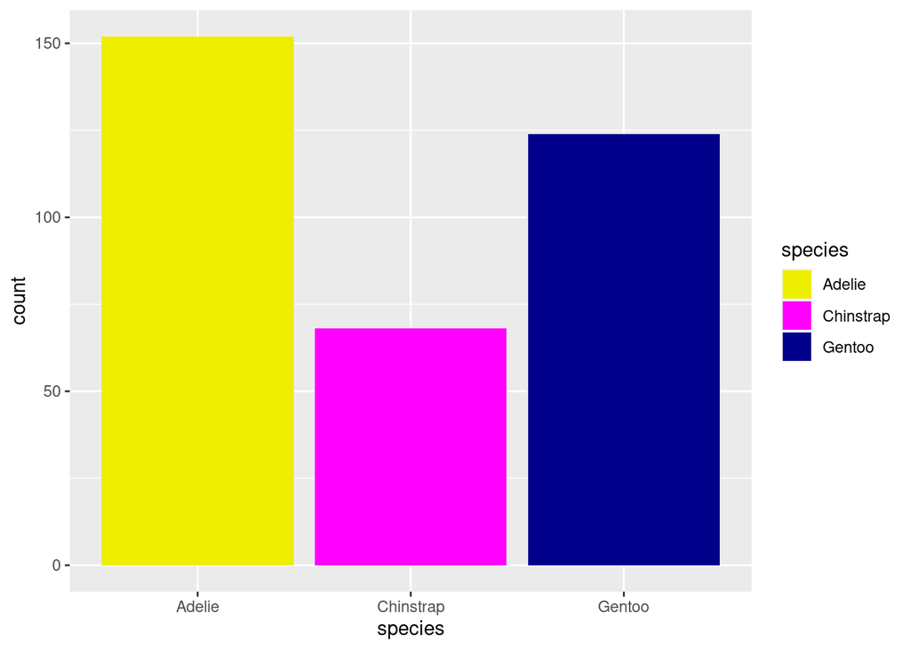

```r
s_counts <- penguins %>% ggplot(aes(x = species, fill = species)) +
  geom_bar()

s_counts + scale_fill_manual(values = c("yellow2", "magenta", "darkblue"))
```

You can also put together a vector of your favourite colours and use that instead. However, it’s a good idea to use established colour palettes to make sure the colours are well-balanced and colour-blind friendly. ggplot2 has several built-in colour palettes that are based on colour packages. For discrete colours we can use scales with palettes from “ColorBrewer” (https://colorbrewer2.org/).

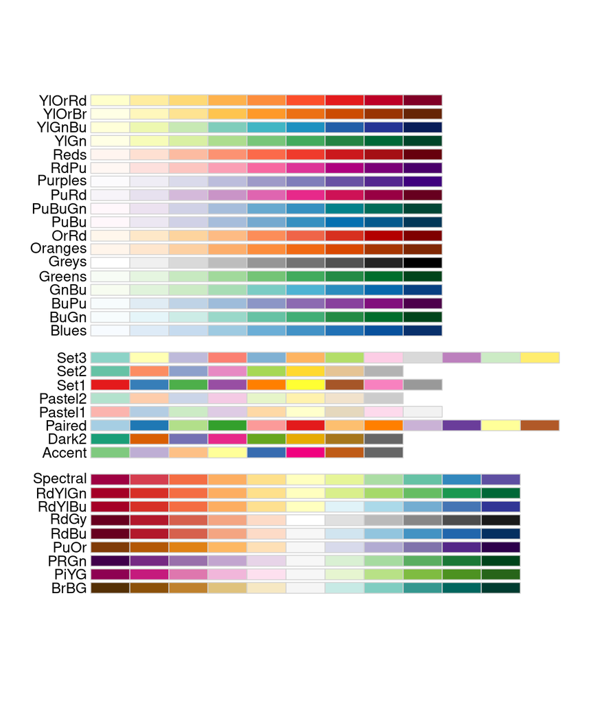

```r
install.packages("RColorBrewer")
library(RColorBrewer)
display.brewer.all()
```

ColorBrewer has three types of palettes: The first type is suitable for ranked discrete graphs, e.g. a series of years. The second is best for our example plot of unranked categorical data. The third type is used when you have discrete diverging data going from low to high through 0.

We can apply ColorBrewer palettes like this:

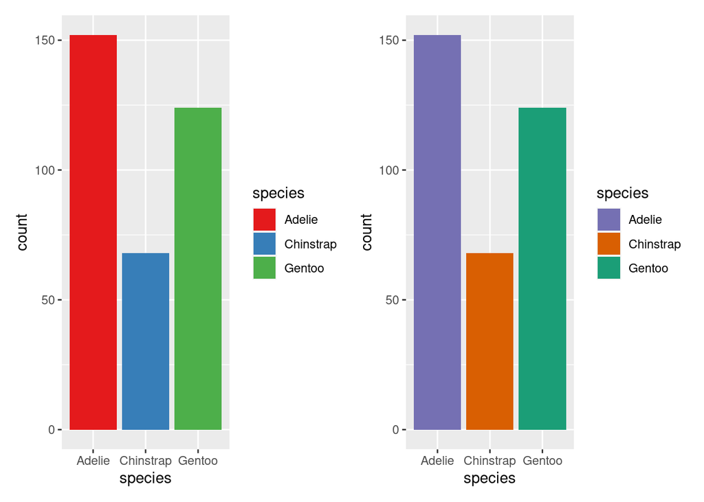

```r
brew_1 <- s_counts + scale_fill_brewer(palette = "Set1")
brew_2 <- s_counts + scale_fill_brewer(palette = "Dark2", direction = -1)

brew_1 + brew_2
```

You will notice that the colours in the first graph aren’t great because the red and green will be hard to distinguish for people with colour blindness. The viridis scales are designed to be colour-blind friendly:

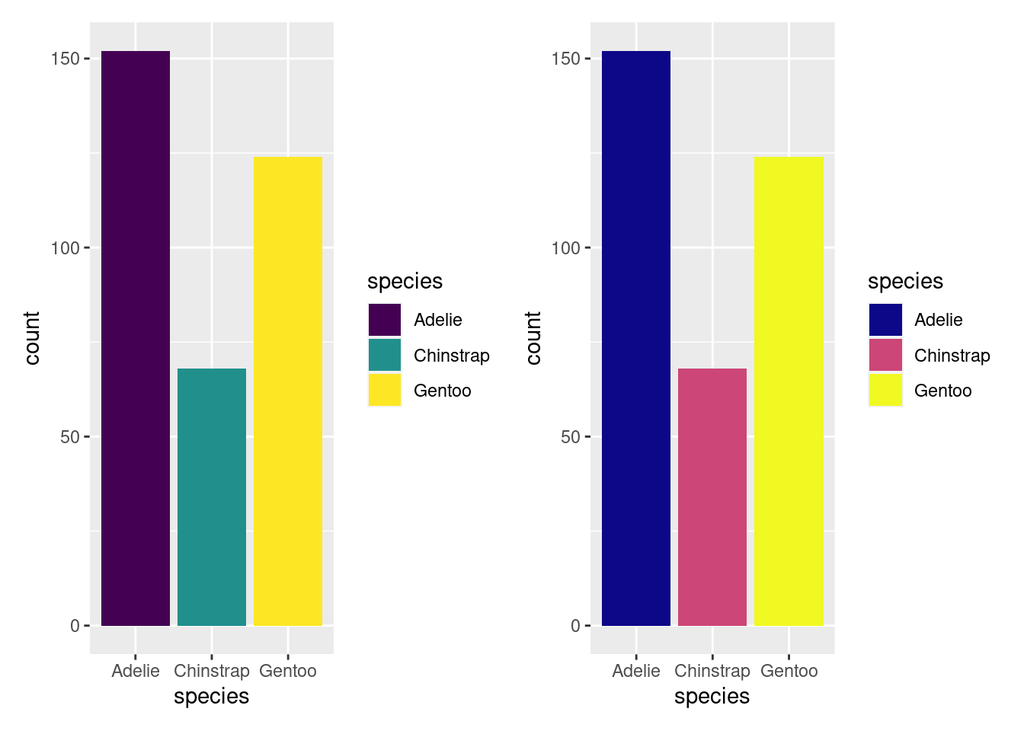

```r
viri_1 <- s_counts + scale_fill_viridis_d() #Uses default option viridis
viri_2 <- s_counts + scale_fill_viridis_d(option = "plasma")

viri_1 + viri_2
```

## Continuous colour scales

Similar to discrete scales you can manipulate continuous scales as well. The function for continuous viridis scales is `scale_colour_viridis_c()` and for ColorBrewer `scale_colour_distiller()`.

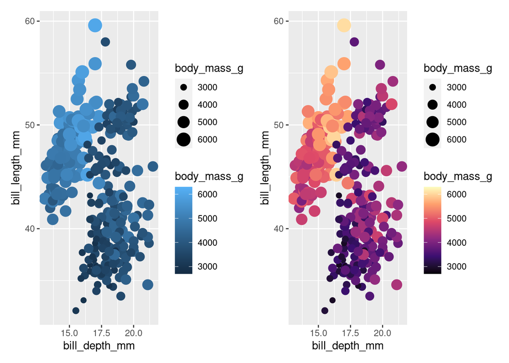

```r
con_plot_1 <- penguins %>% drop_na() %>%
  ggplot(aes(x = bill_depth_mm, y = bill_length_mm)) +
  geom_point(aes(size = body_mass_g, colour = body_mass_g))

con_plot_2 <- con_plot_1 + scale_colour_viridis_c(option = "magma")

con_plot_1 + con_plot_2
```

## NA values

If you’re displaying NA values in your graphs it is recommended to give them a colour. Some palette functions have grey set as default for NA whereas others don’t. In the latter case the colour of NA gets sometimes set to the background of the plot. This can have unintended results, for example if you remove the default grey plot background (more on that in the next section).

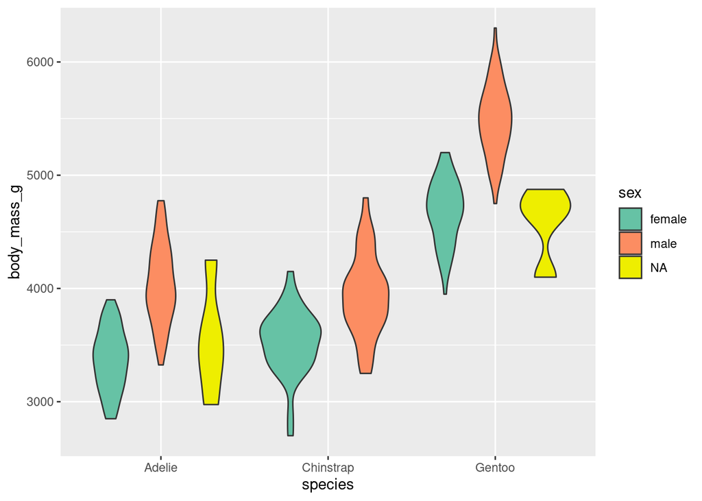

```r
penguins %>%
  ggplot(mapping = aes(x = species, y = body_mass_g)) +
  geom_violin(aes(fill = sex)) +
  scale_fill_brewer(palette = "Set2", na.value = "yellow2")
```

**Copy some of your graph scripts from the last few weeks into this week’s project and see how you can improve your plots with more bespoke colour schemes. Depending on whether you have mapped to `colour` or `fill` you need to change the function accordingly, i.e. either use `scale_colour_brewer()` or `scale_fill_brewer()`. Same goes for `manual` or `viridis`.**

# 6. Themes

ggplot2 has a default theme, `theme_grey()`, that determines the overall look of your plot. It sets the plot panel to grey, grid lines and axes to white, determines where the legend goes, etc. There is a number of other complete themes available, such as `theme_minimal()`, `theme_classic()`, etc. We can simply change from the default to another one like so:

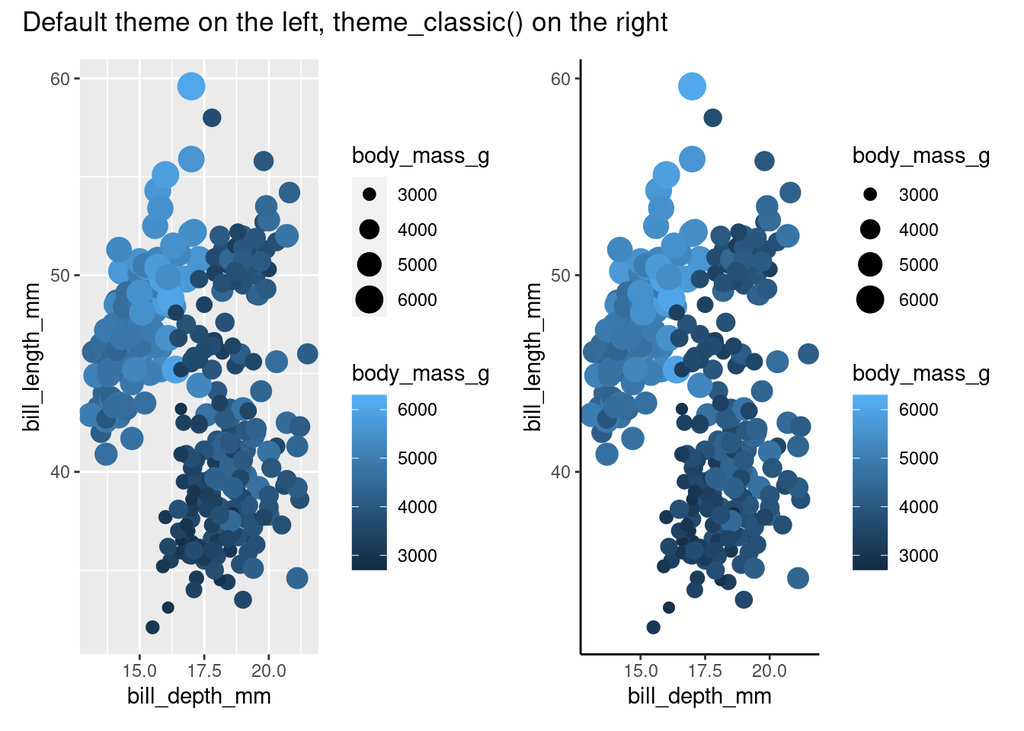

```r
con_plot_3 <- con_plot_1 + theme_classic()

con_plot_1 + con_plot_3 + plot_annotation(title = "Default theme on the left, theme_classic() on the right")
```

The function `theme()` allows us to change each element of the plot.

**Have a look at the documentation of `theme()` for the mind-boggling number of arguments available to adjust every little detail. Then type `theme_grey` (without the brackets) into you console to look at how these arguments are used to set the theme.**

The elements of a plot are divided into three broad types: Lines, text and rectangles. Accordingly, there are three functions that are used to manipulate them: `element_line()`, `element_text()`, and `element_rect()`. If we want to remove an element entirely we use the function `element_blank()`.

Let’s see how this works in practice:

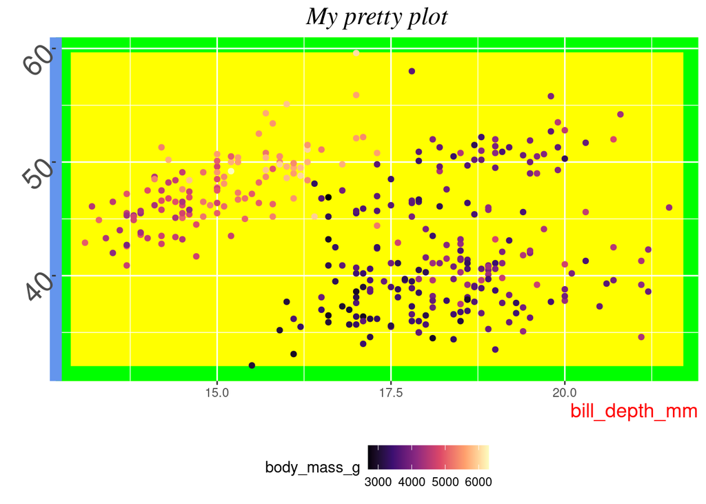

```r
penguins %>% drop_na() %>%
  ggplot(aes(x = bill_depth_mm, y = bill_length_mm)) +
  geom_point(aes(colour = body_mass_g)) +
  labs(title = "My pretty plot") +
  scale_colour_viridis_c(option = "magma") +
  theme(legend.position = "bottom",
        axis.title.x = element_text(colour = "red", size = 14, hjust = 1),
        axis.title.y = element_blank(),
        axis.line.y = element_line(colour = "cornflowerblue", size = 4),
        axis.text.y = element_text(size = 20, angle = 45),
        panel.background = element_rect(colour = "green", fill = "yellow", size = 10),
        plot.title = element_text(family = "Times", face = "italic",  hjust = 0.5, size = 18))
```

The changes I’ve made to the plot are obviously hideous, but they give you a glimpse of what is possible. Removing certain elements, such as axis titles is useful when we combine different plots using patchwork and we don’t want to repeat the same axis names and labels.

One note on fonts: R knows a few basic fonts such as Helvetica, Courier, etc., but most of the time we would stick with the default.

`theme()` is also very handy for adjusting the position of the legend. As you’ve seen above, we can move it below the plot area, but we can also put it in the plot to save space:

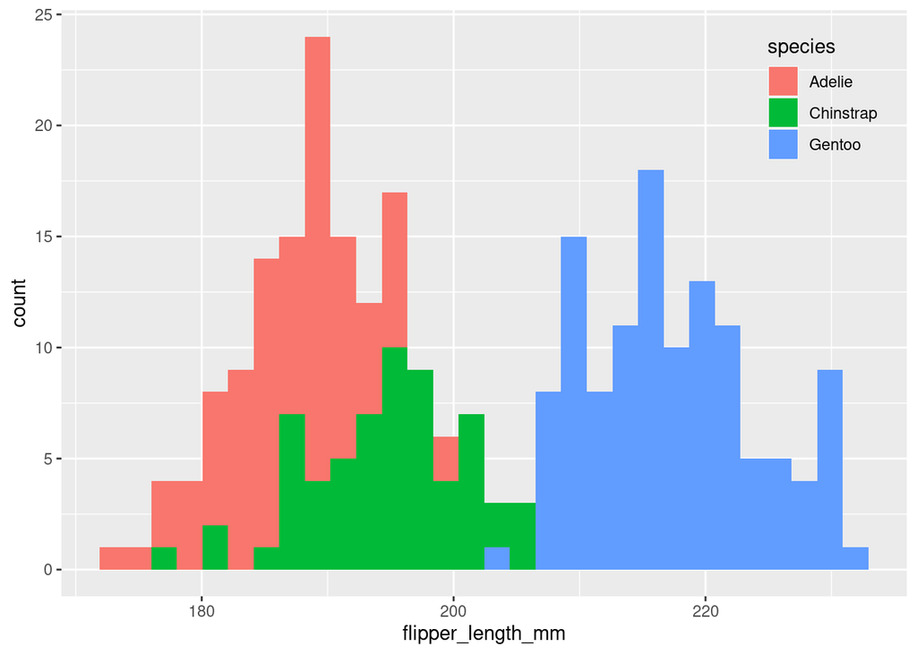

```r
penguins %>%  drop_na() %>%
  ggplot(aes(x = flipper_length_mm)) +
  geom_histogram(aes(fill = species), position = "identity") +
  theme(legend.position = c(0.9,0.85),
           legend.background = element_blank())
```

**Before we get all serious again, have a play with the different elements of a plot. First take the hideous plot code above, and change the set arguments to `theme()` to understand what they do. Then take one of your plots, or produce a new one, and adjust colours, sizes of different text elements, positions, etc. For example, you could try and match the colours of your favourite football team or give your plot a 70s hippie vibe.**

# 7. Big challenge

**Use wmr_modelling.txt to reproduce this plot. High burden countries are defined as having had more than 20,000 deaths in 2020. You don’t have to use the exact colours, but pay attention to the changes of axis labels, legend position and so on.**

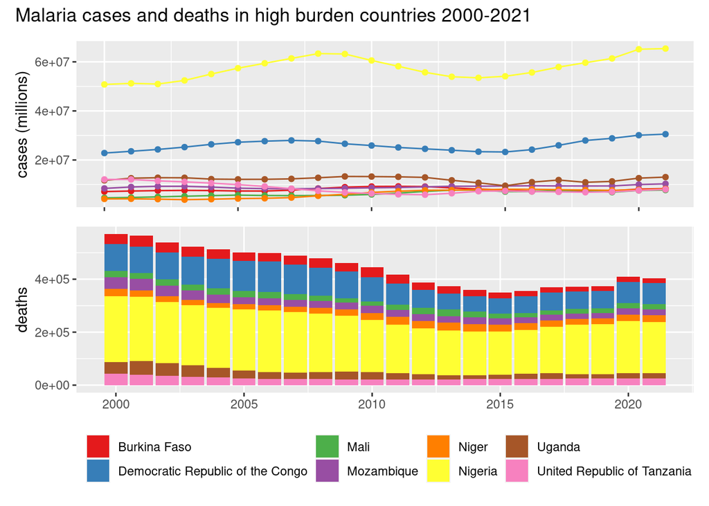